# Classification: Loan Default Prediction

## Build Logistic Regression Model

### Logistic Regression Model - Baseline (lr1)

```python
# Defining the Logistic regression model
lr1 = LogisticRegression(random_state=42)

# Fitting the model on the training data
lr1.fit(X_train, y_train)
```

```
LogisticRegression(random_state=42)
```

**Performance metrics for baseline model lr1:**

```
lr1 train set metrics
              precision    recall  f1-score   support

           0       0.82      0.98      0.89      3339
           1       0.63      0.12      0.21       831

    accuracy                           0.81      4170
   macro avg       0.72      0.55      0.55      4170
weighted avg       0.78      0.81      0.76      4170
```

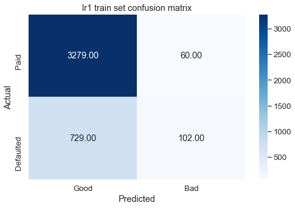

```python
# Predict for train set
y_pred_train = lr1.predict(X_train)

# checking the performance on train dataset
metrics_score('lr1', 'train', y_train, y_pred_train)
```

```
lr1 test set metrics
              precision    recall  f1-score   support

           0       0.82      0.97      0.89      1431
           1       0.56      0.13      0.22       357

    accuracy                           0.81      1788
   macro avg       0.69      0.55      0.55      1788
weighted avg       0.77      0.81      0.75      1788
```

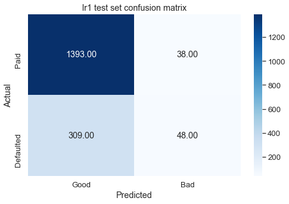

```python
# Predict for test set
y_pred_test = lr1.predict(X_test)

# checking the performance on test dataset
metrics_score('lr1', 'test', y_test, y_pred_test)
```

**Observations on performance of baseline LR model lr1:**

- As can be seen above, Model is highly biased towards class 0.
- The default threshold of the model is 0.5, which means that the model tries to predict class 0 and class 1 with equal probability.
- Since here the data is imbalanced to majority class (class 0), the model is biased to class 0 and giving above result.
- We need to find optimal threshold using Precision-Recall Curve for Logistic Regression to see if it improves model performance.

**Precision-Recall Curve for Logistic Regression**

When making a prediction for a binary or two-class classification problem, there are two types of errors that we could make.

- False Positive. Predict an event when there was no event.
- False Negative. Predict no event when in fact there was an event.

By predicting probabilities and calibrating a threshold, a balance of these two concerns can be chosen by the operator of the model.

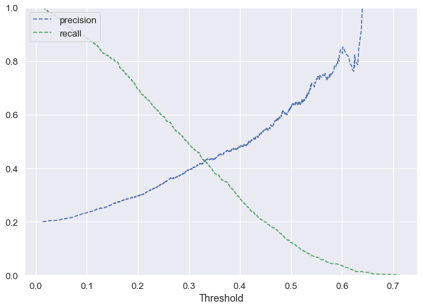

```python
# Code to generate Precision-Recall Curve
# predict_proba gives the probability of each observation belonging to each class
y_scores_train=lr1.predict_proba(X_train)

# let us find the precision, recall threshold for class 1
precisions, recalls, thresholds = precision_recall_curve(y_train, y_scores_train[:,1])

#Plot values of precisions, recalls, and thresholds
plt.figure(figsize=(10,7))
plt.plot(thresholds, precisions[:-1], 'b--', label='precision')
plt.plot(thresholds, recalls[:-1], 'g--', label = 'recall')
plt.xlabel('Threshold')
plt.legend(loc='upper left')
plt.ylim([0,1])
plt.show()
```

```python
# Calculating optimal threshold where precision and recall are equal.
for i in np.arange(len(thresholds)):
    if precisions[i]==recalls[i]:
        print(thresholds[i])
```

```
0.3314311626651928
```

```
With optimal threshold at  0.3314 for lr1
lr1 train set metrics
              precision    recall  f1-score   support

           0       0.86      0.86      0.86      3339
           1       0.43      0.43      0.43       831

    accuracy                           0.77      4170
   macro avg       0.64      0.64      0.64      4170
weighted avg       0.77      0.77      0.77      4170
```

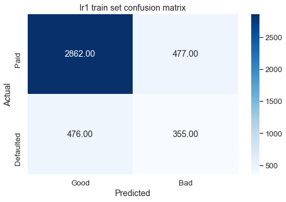

```python
# Checking performance on training dataset at optimal threshold
optimal_threshold1 = 0.3314
print('With optimal threshold at ', optimal_threshold1, 'for lr1')
metrics_score('lr1', 'train', y_train, y_scores_train[:,1]>optimal_threshold1)
```

```
With optimal threshold at  0.3314 for lr1
lr1 test set metrics
              precision    recall  f1-score   support

           0       0.85      0.85      0.85      1431
           1       0.41      0.40      0.40       357

    accuracy                           0.76      1788
   macro avg       0.63      0.63      0.63      1788
weighted avg       0.76      0.76      0.76      1788
```

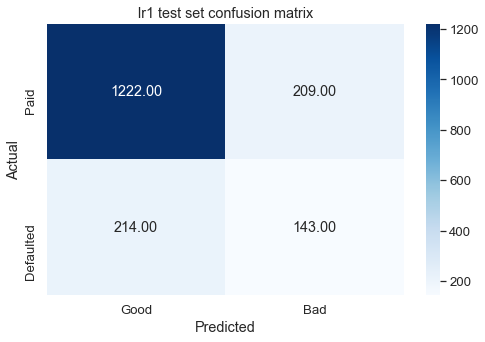

```python
# predict prbabilities for test data
y_scores_test = lr1.predict_proba(X_test)

# Checking performance on testing data at optimal threshold
print('With optimal threshold at ', optimal_threshold1, 'for lr1')
metrics_score('lr1', 'test', y_test, y_scores_test[:,1]>optimal_threshold1)
```

### **Observations:**

At optimal threshold of precision-recall curve for class 1 probability, below are the improved performance metrics for the baseline model lr1:

- **Recall for class 1** has improved from 12% to 43% for training and from 13% to 40% for test data, but it is still very low.
- **Weighted F1-score** is at 76% for optimal threshold Log Reg model.
- Accuracy of the model is 76% which is acceptable.

### Resampling - Oversampling with SMOTE

After looking at the baseline LR model at optimal threshold, let us try another option to handle the imbalanced dataset, that is the resampling method using SMOTE from imblearn module.

SMOTE (Synthetic Minority Oversampling TEchnique) consists of synthesizing elements for the minority class, based on those that already exist. It works randomly picingk a point from the minority class and computing the k-nearest neighbors for this point. The synthetic points are added between the chosen point and its neighbors.

Reference: [SMOTE Official Documentation](https://imbalanced-learn.org/stable/references/generated/imblearn.over_sampling.SMOTE.html).

We will perform the resampling only on training set, as we want to avoid any manipulation of the test data.

```python
#from imblearn.over_sampling import SMOTE

smote = SMOTE(random_state=42)
X_train_res, y_train_res = smote.fit_resample(X_train, y_train)

print(X_train_res.shape, y_train_res.shape)
y_train_res.value_counts()
```

```
(6678, 18) (6678,)
```

```
0    3339
1    3339
Name: BAD, dtype: int64
```

### Logistic Regression Model - using resampled data (lr_res)

```python
# Defining the Logistic regression model 2
lr_res = LogisticRegression(random_state=42)

# Fitting the model on resampled training data sm1
lr_res.fit(X_train_res, y_train_res)
```

```
LogisticRegression(random_state=42)
```

**Performance metrics for model lr_res:**

```
lr_res train set metrics
              precision    recall  f1-score   support

           0       0.71      0.63      0.67      3339
           1       0.67      0.75      0.71      3339

    accuracy                           0.69      6678
   macro avg       0.69      0.69      0.69      6678
weighted avg       0.69      0.69      0.69      6678
```

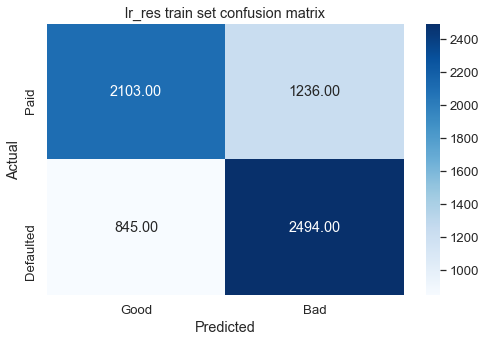

```python
# Predict for resampled train set
y_pred_train_res = lr_res.predict(X_train_res)

# checking the performance on train dataset
metrics_score('lr_res', 'train', y_train_res, y_pred_train_res)
```

```
lr_res test set metrics
              precision    recall  f1-score   support

           0       0.88      0.61      0.72      1431
           1       0.30      0.67      0.42       357

    accuracy                           0.63      1788
   macro avg       0.59      0.64      0.57      1788
weighted avg       0.77      0.63      0.66      1788
```

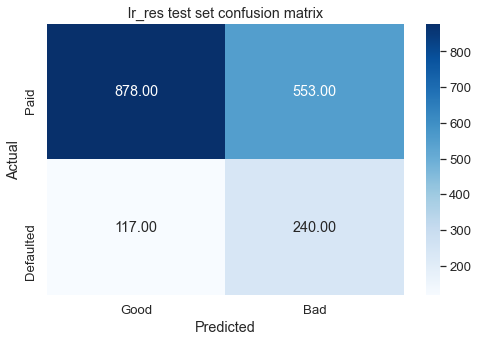

```python
# Predict for test set
y_pred_test2 = lr_res.predict(X_test)

# checking the performance on test dataset
metrics_score('lr_res', 'test', y_test, y_pred_test2)
```

**Insights on Logistic Regression classifier model:**

- As compared to Optimal LogReg, below is the performance analysis of resampled training data LogReg model over test data:
  - **Recall for class 1** has improved from 40% to 67%
  - **Weighted Avg F1-score** has decreased from 76% to 66%.
  - Accuracy of the model is 63%.
- When used stratified split of training and test data, LogReg with resampled data gives best results.

Back to top

### Data preparation for Tree based models:

Tree based classifiers are robust to outliers. Since the partitioning happens based on the proportion of samples within the split ranges and not on absolute values, they are not affected by the range of values, and thus not affected by outliers.

**So we will use the dataset from earlier, without treating outliers. We still need to process this data to replace missing values.**

```python
# Preparaing dataset without treating outliers
df_tree = df1.copy(deep=True)
df_tree.shape
```

```
(5958, 14)
```

**Check for missing values in dataset**

```python
# Checking missing values using pre-defined function
percentage_missing_values(df_tree)
```

```
Percentage missing values per column of given dataset are:
```

|  | Variables | Missing Values | % Missing Values of all data |
| --- | --- | --- | --- |
| 0 | BAD | 0 | 0.00 |
| 1 | LOAN | 0 | 0.00 |
| 2 | MORTDUE | 516 | 8.66 |
| 3 | VALUE | 110 | 1.85 |
| 4 | REASON | 0 | 0.00 |
| 5 | JOB | 0 | 0.00 |
| 6 | YOJ | 513 | 8.61 |
| 7 | DEROG | 706 | 11.85 |
| 8 | DELINQ | 578 | 9.70 |
| 9 | CLAGE | 306 | 5.14 |
| 10 | NINQ | 508 | 8.53 |
| 11 | CLNO | 220 | 3.69 |
| 12 | DEBTINC | 1265 | 21.23 |
| 13 | STATUS | 0 | 0.00 |

#### Replacing Missing Values - WITHOUT treating outliers

```python
# replace missing values in df_new
replace_missing_values(df_tree)
```

|  | BAD | LOAN | MORTDUE | VALUE | REASON | JOB | YOJ | DEROG | DELINQ | CLAGE | NINQ | CLNO | DEBTINC | STATUS |
| --- | --- | --- | --- | --- | --- | --- | --- | --- | --- | --- | --- | --- | --- | --- |
| 0 | 1 | 1100 | 25860.0 | 39025.0 | HomeImp | Other | 10.5 | 0.0 | 0.0 | 94.366667 | 1.0 | 9.0 | 39.387645 | DEFAULTED |
| 1 | 1 | 1300 | 70053.0 | 68400.0 | HomeImp | Other | 7.0 | 0.0 | 2.0 | 121.833333 | 0.0 | 14.0 | 39.387645 | DEFAULTED |
| 2 | 1 | 1500 | 13500.0 | 16700.0 | HomeImp | Other | 4.0 | 0.0 | 0.0 | 149.466667 | 1.0 | 10.0 | 39.387645 | DEFAULTED |
| 4 | 0 | 1700 | 97800.0 | 112000.0 | HomeImp | Office | 3.0 | 0.0 | 0.0 | 93.333333 | 0.0 | 14.0 | 33.253129 | PAID |
| 5 | 1 | 1700 | 30548.0 | 40320.0 | HomeImp | Other | 9.0 | 0.0 | 0.0 | 101.466002 | 1.0 | 8.0 | 37.113614 | DEFAULTED |
| ... | ... | ... | ... | ... | ... | ... | ... | ... | ... | ... | ... | ... | ... | ... |
| 5955 | 0 | 88900 | 57264.0 | 90185.0 | DebtCon | Other | 16.0 | 0.0 | 0.0 | 221.808718 | 0.0 | 16.0 | 36.112347 | PAID |
| 5956 | 0 | 89000 | 54576.0 | 92937.0 | DebtCon | Other | 16.0 | 0.0 | 0.0 | 208.692070 | 0.0 | 15.0 | 35.859971 | PAID |
| 5957 | 0 | 89200 | 54045.0 | 92924.0 | DebtCon | Other | 15.0 | 0.0 | 0.0 | 212.279697 | 0.0 | 15.0 | 35.556590 | PAID |
| 5958 | 0 | 89800 | 50370.0 | 91861.0 | DebtCon | Other | 14.0 | 0.0 | 0.0 | 213.892709 | 0.0 | 16.0 | 34.340882 | PAID |
| 5959 | 0 | 89900 | 48811.0 | 88934.0 | DebtCon | Other | 15.0 | 0.0 | 0.0 | 219.601002 | 0.0 | 16.0 | 34.571519 | PAID |

5958 rows × 14 columns

```python
# Checking missing values using pre-defined function
percentage_missing_values(df_tree)
```

```
Percentage missing values per column of given dataset are:
```

|  | Variables | Missing Values | % Missing Values of all data |
| --- | --- | --- | --- |
| 0 | BAD | 0 | 0.0 |
| 1 | LOAN | 0 | 0.0 |
| 2 | MORTDUE | 0 | 0.0 |
| 3 | VALUE | 0 | 0.0 |
| 4 | REASON | 0 | 0.0 |
| 5 | JOB | 0 | 0.0 |
| 6 | YOJ | 0 | 0.0 |
| 7 | DEROG | 0 | 0.0 |
| 8 | DELINQ | 0 | 0.0 |
| 9 | CLAGE | 0 | 0.0 |
| 10 | NINQ | 0 | 0.0 |
| 11 | CLNO | 0 | 0.0 |
| 12 | DEBTINC | 0 | 0.0 |
| 13 | STATUS | 0 | 0.0 |

Back to top

#### Separating the target variable y and independent variable x

```python
# Drop dependent variable from dataframe and create the X (independent variable) matrix
tr_X = df_tree.drop(columns = ['BAD', 'STATUS'])

# Create dummy variables for the categorical variables - Hint: use the get_dummies() function
tr_X = pd.get_dummies(tr_X, drop_first=True)

# Create y (dependent variable)
tr_y = df_tree['BAD']
```

```python
tr_X.columns
```

```
Index(['LOAN', 'MORTDUE', 'VALUE', 'YOJ', 'DEROG', 'DELINQ', 'CLAGE', 'NINQ',
       'CLNO', 'DEBTINC', 'REASON_HomeImp', 'REASON_Unknown', 'JOB_Office',
       'JOB_Other', 'JOB_ProfExe', 'JOB_Sales', 'JOB_Self', 'JOB_Unknown'],
      dtype='object')
```

```python
len(tr_X.columns)
```

```
18
```

#### Split the data for tree based models

```python
# Split the data into training and test set using 80:20 ratio

X_train_tr, X_test_tr, y_train_tr, y_test_tr = train_test_split(tr_X, tr_y, test_size=0.20, stratify=y, random_state=42)
```

## Build a Decision Tree Model

#### Build and fit the Decision tree classifier model

```python
#Defining Decision tree model with class weights class_weight={0: 0.2, 1: 0.8}

dt1 = DecisionTreeClassifier(random_state=42, class_weight={0:0.2, 1:0.8})

#fitting Decision tree model
dt1.fit(X_train_tr, y_train_tr)
```

```
DecisionTreeClassifier(class_weight={0: 0.2, 1: 0.8}, random_state=42)
```

**Performance metrics for baseline model dt1:**

```
dt1 train set metrics
              precision    recall  f1-score   support

           0       1.00      1.00      1.00      3816
           1       1.00      1.00      1.00       950

    accuracy                           1.00      4766
   macro avg       1.00      1.00      1.00      4766
weighted avg       1.00      1.00      1.00      4766
```

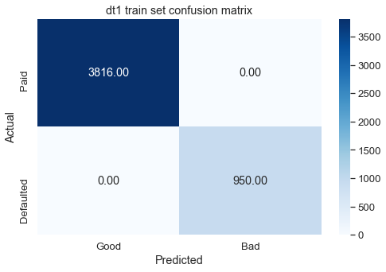

```python
# Checking performance on the training data

# Predict for train set
y_pred_train_dt1 = dt1.predict(X_train_tr)

# checking the performance on train dataset
metrics_score('dt1', 'train', y_train_tr, y_pred_train_dt1)
```

```
dt1 test set metrics
              precision    recall  f1-score   support

           0       0.97      0.97      0.97       954
           1       0.88      0.88      0.88       238

    accuracy                           0.95      1192
   macro avg       0.92      0.92      0.92      1192
weighted avg       0.95      0.95      0.95      1192
```

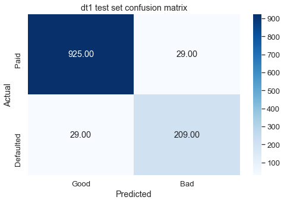

```python
# Checking performance on testing data

# Predict for test set
y_pred_test_dt1 = dt1.predict(X_test_tr)

# checking the performance on test dataset
metrics_score('dt1', 'test', y_test_tr, y_pred_test_dt1)
```

**Insights about baseline DT model dt1:**

- Decision tree baseline model is overfitted on training data with 100% score across all metrics in the classification report.
- For test data, the baseline DT model gives a recall score of 88% for class 1, and a weighted F1 score of 95%, and also an accuracy of 95%
- Although model seems overfitted, the test data metrics are comparable to train data.

#### **Decision Tree - Hyperparameter Tuning**

- Hyperparameter tuning is tricky in the sense that **there is no direct way to calculate how a change in the hyperparameter value will reduce the loss of your model**, so we usually resort to experimentation. We'll use Grid search to perform hyperparameter tuning.
- **Grid search is a tuning technique that attempts to compute the optimum values of hyperparameters.**
- **It is an exhaustive search** that is performed on the specific parameter values of a model.
- The parameters of the estimator/model used to apply these methods are **optimized by cross-validated grid-search** over a parameter grid.

**Using GridSearchCV for Hyperparameter tuning of Decision Tree**

```python
# Choose the type of classifier.
dt_tuned = DecisionTreeClassifier(class_weight={0:0.2, 1:0.8}, random_state=42)

# Grid of parameters to choose from
parameters = {'criterion': ['gini', 'entropy'],
              'max_depth': np.arange(4,8),
              'min_samples_leaf': np.arange(1,50)
             }

# Type of scoring used to compare parameter combinations
scorer = metrics.make_scorer(recall_score, pos_label=1)

# Run the grid search
grid_obj = GridSearchCV(dt_tuned, parameters, scoring=scorer, cv=5)

# Fit the GridSearch on train dataset
grid_obj = grid_obj.fit(X_train_tr, y_train_tr)

grid_obj.best_params_
```

```
{'criterion': 'entropy', 'max_depth': 7, 'min_samples_leaf': 36}
```

```python
grid_obj.best_score_
```

```
0.8368421052631578
```

```python
# Set the classifier to best combination of parameters
dt_tuned = grid_obj.best_estimator_
```

```python
# Fit the best algorithm to the data.
dt_tuned.fit(X_train_tr, y_train_tr)
```

```
DecisionTreeClassifier(class_weight={0: 0.2, 1: 0.8}, criterion='entropy',
                       max_depth=7, min_samples_leaf=36, random_state=42)
```

### Tuned Decision Tree model (dt_tuned)

**Performance metrics for tuned model dt_tuned:**

```
dt_tuned train set metrics
              precision    recall  f1-score   support

           0       0.97      0.92      0.94      3816
           1       0.73      0.88      0.80       950

    accuracy                           0.91      4766
   macro avg       0.85      0.90      0.87      4766
weighted avg       0.92      0.91      0.91      4766
```

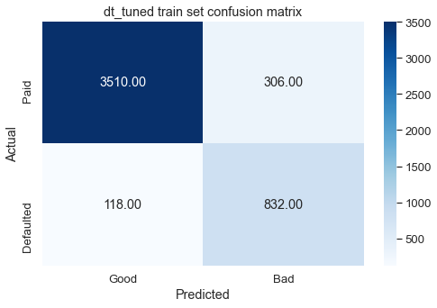

```python
# Checking performance on the training data based on the tuned model

# Predict for train set
y_pred_train_dt2 = dt_tuned.predict(X_train_tr)

# checking the performance on train dataset
metrics_score('dt_tuned', 'train', y_train_tr, y_pred_train_dt2)
```

```
dt_tuned test set metrics
              precision    recall  f1-score   support

           0       0.96      0.90      0.93       954
           1       0.69      0.85      0.76       238

    accuracy                           0.89      1192
   macro avg       0.82      0.88      0.85      1192
weighted avg       0.91      0.89      0.90      1192
```

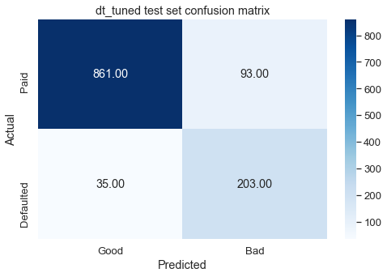

```python
# Checking performance on the testing data based on the tuned model

# Predict for test set
y_pred_test_dt2 = dt_tuned.predict(X_test_tr)

# checking the performance on test dataset
metrics_score('dt_tuned', 'test', y_test_tr, y_pred_test_dt2)
```

### **Feature Importances for tuned Decision Tree Model**

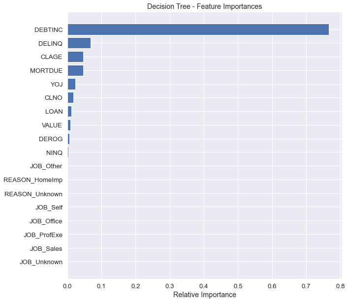

```python
#Plotting the feature importance

importances = dt_tuned.feature_importances_
indices = np.argsort(importances)
features = tr_X.columns
plt.figure(figsize=(10,10))
plt.title('Decision Tree - Feature Importances')
plt.barh(range(len(indices)), importances[indices],  align='center')
plt.yticks(range(len(indices)), [features[i] for i in indices])
plt.xlabel('Relative Importance')
plt.show()
```

**Observation on Decision Tree Feature importances:**

- DEBTINC and DELINQ are the most important discriminators of the target classes.
- CLAGE is third most important class discriminator
- MORTDUE, YOJ, CLNO, LOAN, VALUE, DEROG and NINQ are all of the remaining import features deciding the separation of classes in this model.
- The features REASON and JOB do not seem to have discriminating power over the target classes.

### Plotting the Decision Tree

[figure not shown]

```python
# Plot the decision  tree and analyze it to build the decision rule
features = list(tr_X.columns)

plt.figure(figsize=(80,40))

tree.plot_tree(dt_tuned, feature_names=features, filled=True, fontsize=9, node_ids=True, class_names=True)

plt.show()
```

**Insights on tuned decision tree model - visual analysis:**

In this decision tree, **Blue** nodes indicate the "Defaulted" loans (class 1) and **Orange** nodes indicate "Paid" loans (class 0).

- As per nodes # 68, 69, the classification of class 1 (496) records is when DEBTINC<=39.388; this is indicated by a dark blue end node # 69
- Similarly, for DEBTINC>44.565 (right of node # 70), class 1 is the dominant class indicated by the nodes in dark blue color (# 88, 89, 90)
- For DEBTINC<=44.565 (high) and DELINQ<=0.5 (low), class 0 is the dominant class (most nodes are orange to dark orange) with an exception of 53 records for CLAGE>146.93 and YOJ> 8.96. This looks like anomalous classification.
- For DEBTINC<=44.565 and DELINQ>0.5, for a CLAGE<=208.2, class 1 is the dominant class (nodes # 83, 84, 85, 86)
- On the left side of base node, class 0 is the dominant class for DEBTINC<=39.387
- As can be seen from node # 60, if the DELINQ>0.5 and DEROG>0.5, class 1 is dominant
- As can be seen on the sub-tree with DELINQ>1.5 (nodes # 61, 63, 65, 66, 67), variables VALUE, MORTDUE are major dicriminators for class 1
- MORTDUE and CLNO are also predicting class 1 on the far left side of the decision tree, at nodes # 6, 11

Back to top

## Building a Random Forest Classifier model

**Random Forest is a bagging algorithm where the base models are Decision Trees.** Samples are taken from the training data and on each sample a decision tree makes a prediction. The results from all the decision trees are combined together and the final prediction is made using voting or averaging.

**We will use class weights {0: 0.2, 1: 0.8} in order to balance the imbalanced data.**

```python
# Defining Random forest CLassifier with class weights {0: 0.2, 1: 0.8}
rf1 = RandomForestClassifier(class_weight={0: 0.2, 1: 0.8}, random_state=42)

# fitting rf classifier on training data
rf1.fit(X_train_tr, y_train_tr)
```

```
RandomForestClassifier(class_weight={0: 0.2, 1: 0.8}, random_state=42)
```

#### Checking the performance on the train dataset

```
rf1 train set metrics
              precision    recall  f1-score   support

           0       1.00      1.00      1.00      3816
           1       1.00      1.00      1.00       950

    accuracy                           1.00      4766
   macro avg       1.00      1.00      1.00      4766
weighted avg       1.00      1.00      1.00      4766
```

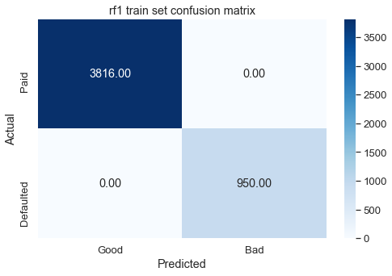

```python
# Checking performance on the training data

# Predict for train set
y_pred_train_rf1 = rf1.predict(X_train_tr)

# checking the performance on train dataset
metrics_score('rf1', 'train', y_train_tr, y_pred_train_rf1)
```

#### Checking the performance on the test dataset

```
rf1 test set metrics
              precision    recall  f1-score   support

           0       0.97      1.00      0.98       954
           1       0.99      0.86      0.92       238

    accuracy                           0.97      1192
   macro avg       0.98      0.93      0.95      1192
weighted avg       0.97      0.97      0.97      1192
```

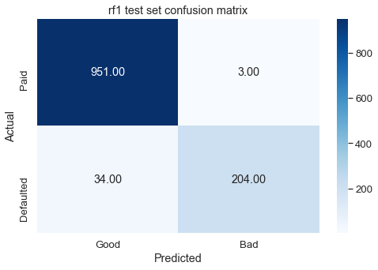

```python
# Checking performance on the test data

# Predict for test set
y_pred_test_rf1 = rf1.predict(X_test_tr)

# checking the performance on test dataset
metrics_score('rf1', 'test', y_test_tr, y_pred_test_rf1)
```

#### Hyperparameter Tuning using GridSearchCV for Random Forest classifier:

- Hyperparameter tuning is tricky in the sense that **there is no direct way to calculate how a change in the hyperparameter value will reduce the loss of your model**, so we usually resort to experimentation. We'll use Grid search to perform hyperparameter tuning.
- **Grid search is a tuning technique that attempts to compute the optimum values of hyperparameters.**
- **It is an exhaustive search** that is performed on the specific parameter values of a model.
- The parameters of the estimator/model used to apply these methods are **optimized by cross-validated grid-search** over a parameter grid.

```python
# Choose the type of classifier.
rf_tuned = RandomForestClassifier(criterion='entropy', class_weight={0:0.2, 1:0.8}, random_state=42)

# Grid of parameters to choose from
parameters1 = {
                "max_features": [0.8,0.9],
                "max_depth": [6,7,8,9],
                "min_samples_leaf": [50, 75, 100],
                "n_estimators": [10,30],
                "max_samples" : [0.8,0.9]
             }

# Type of scoring used to compare parameter combinations
scorer1 = metrics.make_scorer(recall_score, pos_label=1)

# Run the grid search
grid_obj1 = GridSearchCV(rf_tuned, parameters1, scoring=scorer1, cv=5)

#fit the GridSearch on train dataset
grid_obj1 = grid_obj1.fit(X_train_tr, y_train_tr)

grid_obj1.best_params_
```

```
{'max_depth': 9,
 'max_features': 0.8,
 'max_samples': 0.9,
 'min_samples_leaf': 75,
 'n_estimators': 10}
```

```python
grid_obj1.best_score_
```

```
0.8084210526315789
```

```python
# Set the rf classifier to the best combination of parameters
rf_tuned = grid_obj1.best_estimator_

# Fit the best algorithm to the data.
rf_tuned.fit(X_train_tr, y_train_tr)
```

```
RandomForestClassifier(class_weight={0: 0.2, 1: 0.8}, criterion='entropy',
                       max_depth=9, max_features=0.8, max_samples=0.9,
                       min_samples_leaf=75, n_estimators=10, random_state=42)
```

### Tuned Random Forest model (rf_tuned)

#### Checking the performance on the train dataset

```
rf_tuned train set metrics
              precision    recall  f1-score   support

           0       0.95      0.96      0.95      3816
           1       0.82      0.82      0.82       950

    accuracy                           0.93      4766
   macro avg       0.89      0.89      0.89      4766
weighted avg       0.93      0.93      0.93      4766
```

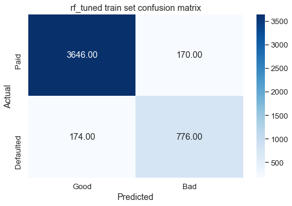

```python
# Checking performance on the training data for tuned rf model
# Predict for train set
y_pred_train_rf2 = rf_tuned.predict(X_train_tr)

# checking the performance on train dataset
metrics_score('rf_tuned', 'train', y_train_tr, y_pred_train_rf2)
```

**Checking the performance on the test dataset**

```
rf_tuned test set metrics
              precision    recall  f1-score   support

           0       0.95      0.96      0.96       954
           1       0.83      0.82      0.82       238

    accuracy                           0.93      1192
   macro avg       0.89      0.89      0.89      1192
weighted avg       0.93      0.93      0.93      1192
```

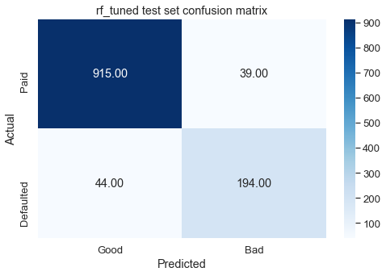

```python
# Checking performace on test dataset data for tuned rf model
# Predict for test set
y_pred_test_rf2 = rf_tuned.predict(X_test_tr)

# checking the performance on test dataset
metrics_score('rf_tuned', 'test', y_test_tr, y_pred_test_rf2)
```

### Feature importance of the tuned Random Forest

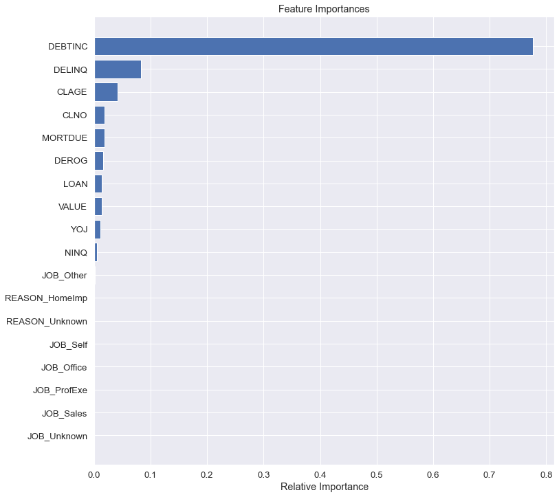

```python
# importance of features in the tree building ( The importance of a feature is computed as the
#(normalized) total reduction of the criterion brought by that feature. It is also known as the Gini importance


importances = rf_tuned.feature_importances_
indices = np.argsort(importances)
feature_names = list(tr_X.columns)

plt.figure(figsize=(12,12))
plt.title('Feature Importances')
plt.barh(range(len(indices)), importances[indices], align='center')
plt.yticks(range(len(indices)), [feature_names[i] for i in indices])
plt.xlabel('Relative Importance')
plt.show()
```

Back to top

## Conclusion:

**End Note:** This Solution notebook is part of the final submission. Please refer to Final Project Report for detailed summary of the project, detailed solution summary, and recommendations to the business.

Back to top